## In-class worksheet 9

**Feb 17, 2015**

# 1. PCA of the iris data set

The iris species versicolor and virginica are difficult to distinguish:

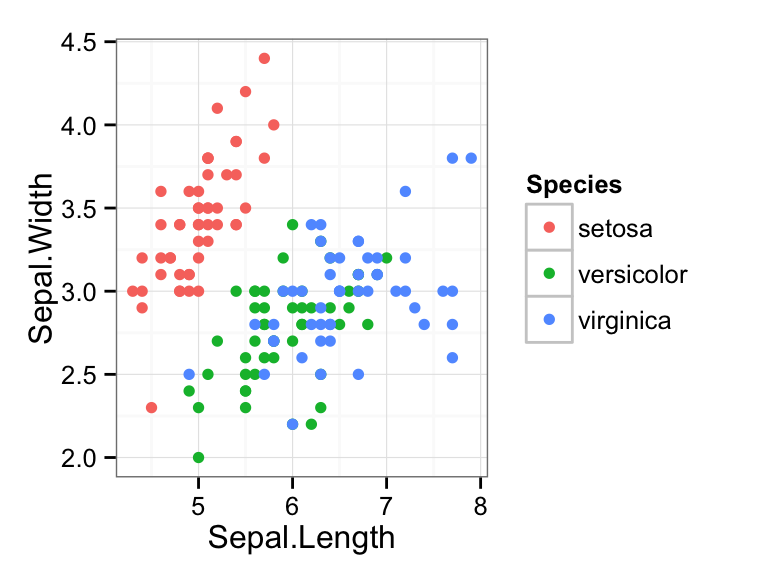

```r
ggplot(iris, aes(x=Sepal.Length, y=Sepal.Width, color=Species)) + geom_point()
```

However, we can separate them if we consider all four variables at the same time, via PCA (principal components analysis). The basic steps in PCA are to (i) prepare a data frame that holds only the numerical columns of interest, (ii) scale the data to 0 mean and unit variance, and (iii) do the PCA with the function `prcomp()`:

```r
iris %>% select(-Species) %>% # remove Species column
  scale() %>%                 # scale to 0 mean and unit variance
  prcomp() ->                 # do PCA
  pca                         # store result as `pca`

# now display the results from the PCA analysis
pca
```

```
## Standard deviations:
## [1] 1.7084 0.9560 0.3831 0.1439
##
## Rotation:
##                  PC1      PC2     PC3     PC4
## Sepal.Length  0.5211 -0.37742  0.7196  0.2613
## Sepal.Width  -0.2693 -0.92330 -0.2444 -0.1235
## Petal.Length  0.5804 -0.02449 -0.1421 -0.8014
## Petal.Width   0.5649 -0.06694 -0.6343  0.5236
```

The main results from PCA are the standard deviations and the rotation matrix. We will talk about them below. First, though, let’s plot the data in the principal components. Specifically, we will plot PC2 vs. PC1. The rotated data are available as `pca$x`:

```r
head(pca$x)
```

```
##         PC1     PC2      PC3       PC4
## [1,] -2.257 -0.4784  0.12728  0.024088
## [2,] -2.074  0.6719  0.23383  0.102663
## [3,] -2.356  0.3408 -0.04405  0.028282
## [4,] -2.292  0.5954 -0.09099 -0.065735
## [5,] -2.382 -0.6447 -0.01569 -0.035803
## [6,] -2.069 -1.4842 -0.02688  0.006586
```

As we can see, these data don’t tell us to which species which observation belongs. We have to add the species information back in:

```r
# add species information back into PCA data
pca_data <- data.frame(pca$x, Species=iris$Species)
head(pca_data)
```

```
##      PC1     PC2      PC3       PC4 Species
## 1 -2.257 -0.4784  0.12728  0.024088  setosa
## 2 -2.074  0.6719  0.23383  0.102663  setosa
## 3 -2.356  0.3408 -0.04405  0.028282  setosa
## 4 -2.292  0.5954 -0.09099 -0.065735  setosa
## 5 -2.382 -0.6447 -0.01569 -0.035803  setosa
## 6 -2.069 -1.4842 -0.02688  0.006586  setosa
```

Now we can plot as usual:

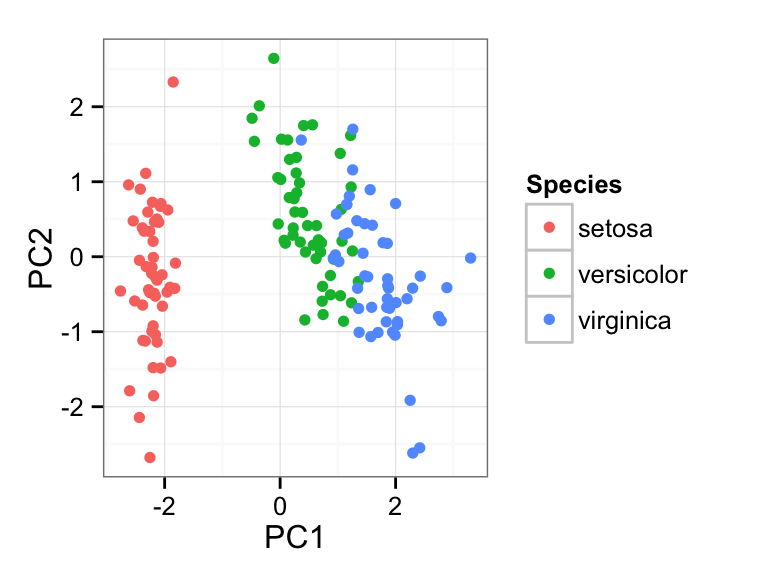

```r
ggplot(pca_data, aes(x=PC1, y=PC2, color=Species)) + geom_point()
```

In the PC2 vs PC1 plot, versicolor and virginica are much better separated.

Next, let’s look at the rotation matrx:

```r
pca$rotation
```

```
##                  PC1      PC2     PC3     PC4
## Sepal.Length  0.5211 -0.37742  0.7196  0.2613
## Sepal.Width  -0.2693 -0.92330 -0.2444 -0.1235
## Petal.Length  0.5804 -0.02449 -0.1421 -0.8014
## Petal.Width   0.5649 -0.06694 -0.6343  0.5236
```

It tells us how much each variable contributes to each principal component. For example, `Sepal.Width` contributes little to PC1 but makes up much of PC2. Often it is helpful to plot the rotation matrix as arrows. This can be done as follows:

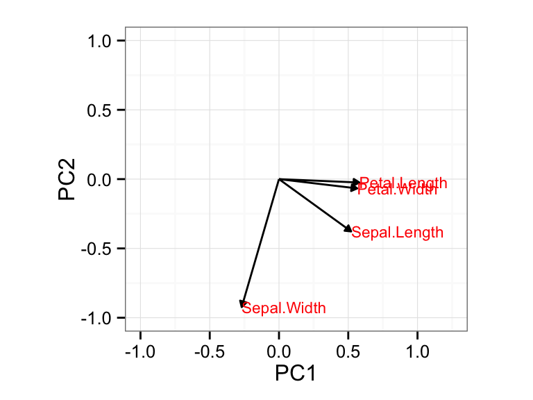

```r
# capture the rotation matrix in a data frame
rotation_data <- data.frame(pca$rotation, variable=row.names(pca$rotation))
# define a pleasing arrow style
arrow_style <- arrow(length = unit(0.05, "inches"),
                     type = "closed")
# now plot, using geom_segment() for arrows and geom_text for labels
ggplot(rotation_data) +
  geom_segment(aes(xend=PC1, yend=PC2), x=0, y=0, arrow=arrow_style) +
  geom_text(aes(x=PC1, y=PC2, label=variable), hjust=0, size=3, color='red') +
  xlim(-1.,1.25) +
  ylim(-1.,1.) +
  coord_fixed() # fix aspect ratio to 1:1
```

We can now see clearly that `Petal.Length`, `Petal.Width`, and `Sepal.Length` all contribute to PC1, and `Sepal.Width` dominates PC2.

Finally, we want to look at the percent variance explained. The `prcomp()` function gives us standard deviations (stored in `pca$sdev`). To convert them into percent variance explained, we square them and then divide by the sum over all squared standard deviations:

```r
percent <- 100*pca$sdev^2/sum(pca$sdev^2)
percent
```

```
## [1] 72.9624 22.8508  3.6689  0.5179
```

The first component explains 73% of the variance, the second 23%, the third 4% and the last 0.5%. We can visualize these results nicely in a bar plot:

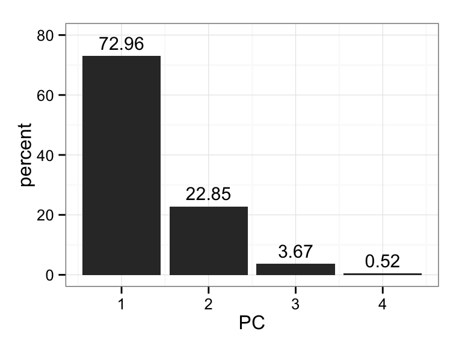

```r
perc_data <- data.frame(percent=percent, PC=1:length(percent))
ggplot(perc_data, aes(x=PC, y=percent)) +
  geom_bar(stat="identity") +
  geom_text(aes(label=round(percent, 2)), size=4, vjust=-.5) +
  ylim(0, 80)
```

# 2. Now do it yourself: The biopsy data set

*The biopsy data set contains data from 683 patients who had a breast biopsy performed. Each tissue sample was scored according to 9 different characteristics, each on a scale from 1 to 10. Also, for each patient the final outcome (benign/malignant) was known:*

```r
biopsy <- read.csv("http://wilkelab.org/classes/SDS348/data_sets/biopsy.csv")
head(biopsy)
```

```
##   clump_thickness uniform_cell_size uniform_cell_shape marg_adhesion
## 1               5                 1                  1             1
## 2               5                 4                  4             5
## 3               3                 1                  1             1
## 4               6                 8                  8             1
## 5               4                 1                  1             3
## 6               8                10                 10             8
##   epithelial_cell_size bare_nuclei bland_chromatin normal_nucleoli mitoses
## 1                    2           1               3               1       1
## 2                    7          10               3               2       1
## 3                    2           2               3               1       1
## 4                    3           4               3               7       1
## 5                    2           1               3               1       1
## 6                    7          10               9               7       1
##     outcome
## 1    benign
## 2    benign
## 3    benign
## 4    benign
## 5    benign
## 6 malignant
```

*Use PCA to predict the outcome (benign/malignant) from the scored characteristics.*

First we do the PCA:

```r
biopsy %>% select(-outcome) %>% # remove outcome column
  scale() %>%                 # scale to 0 mean and unit variance
  prcomp() ->                 # do PCA
  pca                         # store result as `pca`

# now display the results from the PCA analysis
pca
```

```
## Standard deviations:
## [1] 2.4289 0.8809 0.7343 0.6780 0.6167 0.5494 0.5426 0.5106 0.2973
##
## Rotation:
##                          PC1      PC2        PC3      PC4      PC5
## clump_thickness      -0.3021 -0.14080  0.8663725 -0.10783  0.08032
## uniform_cell_size    -0.3808 -0.04664 -0.0199378  0.20426 -0.14565
## uniform_cell_shape   -0.3776 -0.08242  0.0335109  0.17587 -0.10839
## marg_adhesion        -0.3327 -0.05209 -0.4126473 -0.49317 -0.01957
## epithelial_cell_size -0.3362  0.16440 -0.0877425  0.42738 -0.63669
## bare_nuclei          -0.3351 -0.26126  0.0006915 -0.49862 -0.12477
## bland_chromatin      -0.3457 -0.22808 -0.2130718 -0.01305  0.22767
## normal_nucleoli      -0.3356  0.03397 -0.1342484  0.41711  0.69021
## mitoses              -0.2302  0.90556  0.0804922 -0.25899  0.10504
##                           PC6       PC7      PC8       PC9
## clump_thickness      -0.24252 -0.008516  0.24771 -0.002747
## uniform_cell_size    -0.13903 -0.205434 -0.43630 -0.733211
## uniform_cell_shape   -0.07453 -0.127209 -0.58273  0.667481
## marg_adhesion        -0.65463  0.123830  0.16343  0.046019
## epithelial_cell_size  0.06931  0.211018  0.45867  0.066891
## bare_nuclei           0.60922  0.402790 -0.12665 -0.076510
## bland_chromatin       0.29890 -0.700417  0.38372  0.062241
## normal_nucleoli       0.02152  0.459783  0.07401 -0.022079
## mitoses               0.14835 -0.132117 -0.05354  0.007496
```

Now we plot PC2 vs PC1, colored by outcome:

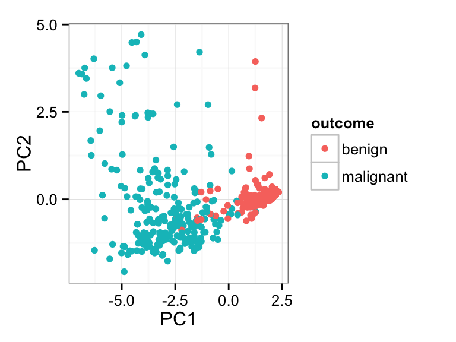

```r
# add outcome information back into PCA data
pca_data <- data.frame(pca$x, outcome=biopsy$outcome)
ggplot(pca_data, aes(x=PC1, y=PC2, color=outcome)) + geom_point()
```

PC1 seems to separate benign from malignant.

Now we’ll take a closer look at the rotation matrix:

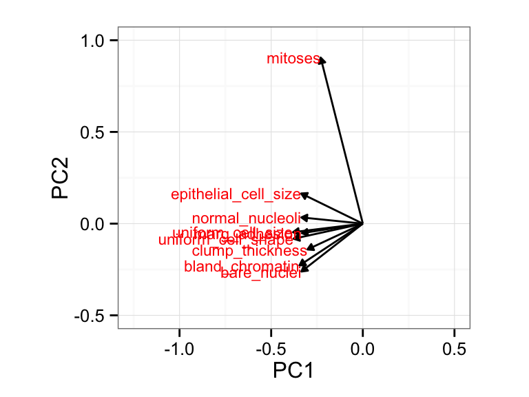

```r
# capture the rotation matrix in a data frame
rotation_data <- data.frame(pca$rotation, variable=row.names(pca$rotation))
# define a pleasing arrow style
arrow_style <- arrow(length = unit(0.05, "inches"),
                     type = "closed")
# now plot, using geom_segment() for arrows and geom_text for labels
ggplot(rotation_data) +
  geom_segment(aes(xend=PC1, yend=PC2), x=0, y=0, arrow=arrow_style) +
  geom_text(aes(x=PC1, y=PC2, label=variable), hjust=1, size=3, color='red') +
  xlim(-1.25,.5) +
  ylim(-.5,1) +
  coord_fixed() # fix aspect ratio to 1:1
```

Nearly all indicators point into the direction of PC1. PC2, which doesn’t predict malignancy, consists mostly of “mitoses.”

Finally, the percent variance explained:

```r
percent <- 100*pca$sdev^2/sum(pca$sdev^2)
percent
```

```
## [1] 65.550  8.622  5.992  5.107  4.225  3.354  3.271  2.897  0.982
```

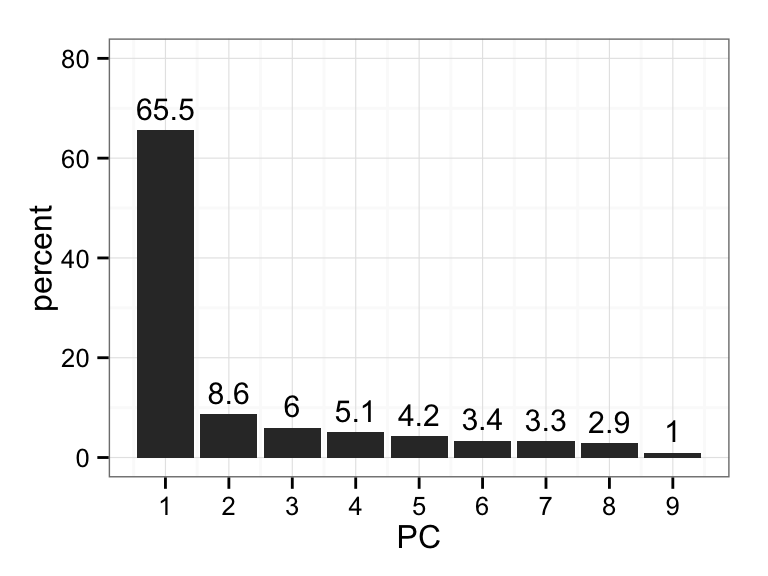

```r
perc_data <- data.frame(percent=percent, PC=1:length(percent))
ggplot(perc_data, aes(x=PC, y=percent)) +
  geom_bar(stat="identity") +
  geom_text(aes(label=round(percent, 1)), size=4, vjust=-.5) +
  ylim(0, 80) +
  scale_x_continuous(breaks=1:9) # make sure each PC gets an axis tick
```

The first PC carries the vast majority of variance explained.

# 3. If this was easy

*The pottery data set contains the chemical composition of ancient pottery found at four sites in Great Britain:*

```r
pottery <- read.csv("http://wilkelab.org/classes/SDS348/data_sets/pottery.csv")
head(pottery)
```

```
##        Site   Al   Fe   Mg   Ca   Na
## 1 Llanedyrn 14.4 7.00 4.30 0.15 0.51
## 2 Llanedyrn 13.8 7.08 3.43 0.12 0.17
## 3 Llanedyrn 14.6 7.09 3.88 0.13 0.20
## 4 Llanedyrn 11.5 6.37 5.64 0.16 0.14
## 5 Llanedyrn 13.8 7.06 5.34 0.20 0.20
## 6 Llanedyrn 10.9 6.26 3.47 0.17 0.22
```

*Use PCA to see whether pottery found at different sites has different chemical composition.*

First we do the PCA:

```r
pottery %>% select(-Site) %>% # remove Site column
  scale() %>%                 # scale to 0 mean and unit variance
  prcomp() ->                 # do PCA
  pca                         # store result as `pca`

# now display the results from the PCA analysis
pca
```

```
## Standard deviations:
## [1] 1.9692 0.7803 0.4942 0.4300 0.2903
##
## Rotation:
##        PC1      PC2       PC3     PC4      PC5
## Al  0.4454  0.35652 -0.694985  0.4360 -0.03679
## Fe -0.4781  0.04118  0.157338  0.6585 -0.55798
## Mg -0.4865 -0.04961 -0.158560  0.3509  0.78265
## Ca -0.4491 -0.34415 -0.683443 -0.3722 -0.27255
## Na -0.3669  0.86620 -0.002043 -0.3386 -0.02180
```

Now we plot PC2 vs PC1, colored by site:

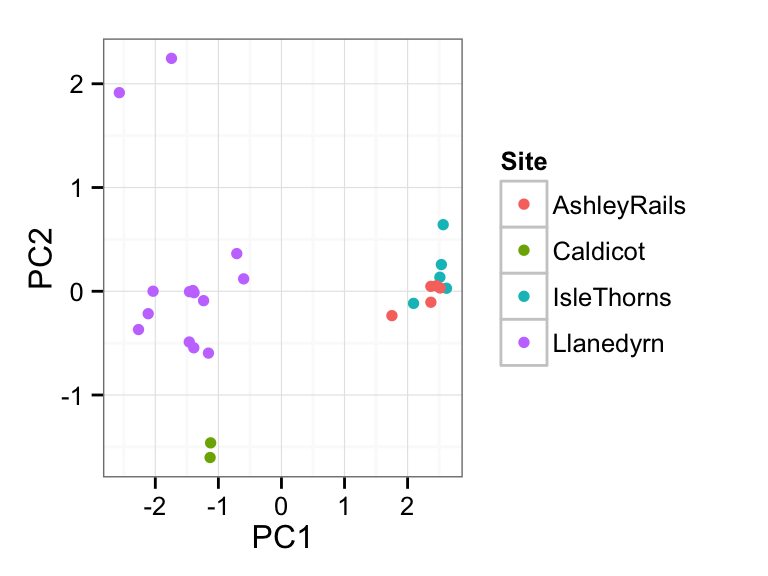

```r
# add outcome information back into PCA data
pca_data <- data.frame(pca$x, Site=pottery$Site)
ggplot(pca_data, aes(x=PC1, y=PC2, color=Site)) + geom_point()
```

Now we’ll take a closer look at the rotation matrix:

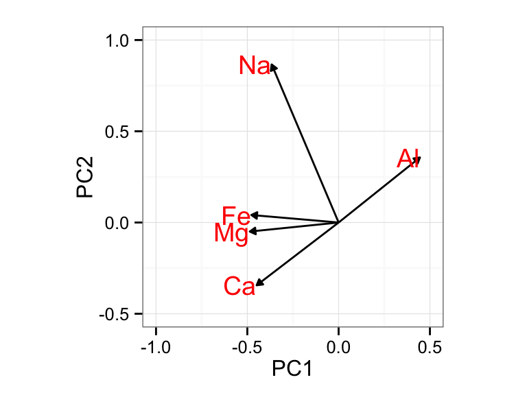

```r
# capture the rotation matrix in a data frame
rotation_data <- data.frame(pca$rotation, variable=row.names(pca$rotation))
# define a pleasing arrow style
arrow_style <- arrow(length = unit(0.05, "inches"),
                     type = "closed")
# now plot, using geom_segment() for arrows and geom_text for labels
ggplot(rotation_data) +
  geom_segment(aes(xend=PC1, yend=PC2), x=0, y=0, arrow=arrow_style) +
  geom_text(aes(x=PC1, y=PC2, label=variable), hjust=1, size=5, color='red') +
  xlim(-1.,.5) +
  ylim(-.5,1) +
  coord_fixed() # fix aspect ratio to 1:1
```

Fe and Mg contribute only to PC1, and the other three elements contribute partially to both PCs.

Finally, the percent variance explained:

```r
percent <- 100*pca$sdev^2/sum(pca$sdev^2)
percent
```

```
## [1] 77.556 12.176  4.884  3.698  1.686
```

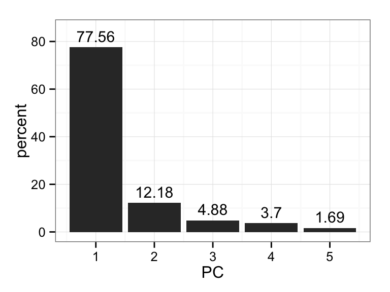

```r
perc_data <- data.frame(percent=percent, PC=1:length(percent))
ggplot(perc_data, aes(x=PC, y=percent)) +
  geom_bar(stat="identity") +
  geom_text(aes(label=round(percent, 2)), size=4, vjust=-.5) +
  ylim(0, 85) +
  scale_x_continuous(breaks=1:5) # make sure each PC gets an axis tick
```

Again, the first PC carries the vast majority of variance explained.